# Ludność według płci i funkcjonalnych grup wieku w Polsce 2013 - 2050

Praca została przygotowana przez: **Maciej Król**, **Michał Bichajło**, **Konrad Lubaski**, **Mateusz Latusek**  
Dane pochodzą z **Głównego Instytutu Statystycznego (GUS)**.  
Źródło danych: [Prognoza ludności 2014-2050](https://demografia.stat.gov.pl/bazademografia/Prognoza_2014_2050.aspx).

## Opis analizy

Analiza koncentruje się na prognozach demograficznych dla Polski w latach 2013-2050. Dane zostały podzielone na trzy główne kategorie:

- **Podział na lokalizacje:** dane zostały przedstawione osobno dla **miast** i **wsi**, co pozwala na analizę różnic demograficznych między tymi obszarami.
- **Podział według płci:** osobno analizowane są dane dla **kobiet** i **mężczyzn**, co pozwala na identyfikację trendów specyficznych dla płci.
- **Wartości ogólne:** analiza obejmuje również dane bez podziału na lokalizacje i płeć, co daje pełny obraz struktury demograficznej kraju.

Dane zostały dodatkowo pogrupowane w pięć funkcjonalnych grup wiekowych:

- **Wiek przedprodukcyjny** (0-17 lat): osoby w wieku dziecięcym i młodzieżowym, które nie uczestniczą jeszcze w rynku pracy.
- **Wiek produkcyjny** (18 lat do wieku emerytalnego): osoby aktywne zawodowo, które stanowią podstawę gospodarki.
- **Wiek poprodukcyjny** (powyżej wieku emerytalnego): osoby w wieku emerytalnym, które zakończyły aktywność zawodową.
- **Wiek mobilny** (18-44 lat): młodsza część populacji produkcyjnej, bardziej skłonna do zmiany miejsca zamieszkania i pracy.
- **Wiek niemobilny** (45 lat do wieku emerytalnego): starsza część populacji produkcyjnej, która jest mniej skłonna do migracji i bardziej ustabilizowana zawodowo.

Te podziały pozwalają na dogłębną analizę demograficzną, identyfikację różnic w trendach i lepsze zrozumienie dynamiki populacji w Polsce.

## Metodologia

Analiza została przeprowadzona przy użyciu następujących narzędzi i technologii:

- **Python**: do obróbki danych i przeprowadzenia analizy statystycznej.
- **Pandas**: do tworzenia tabel przestawnych oraz przekształcania danych.
- **Matplotlib** i **Seaborn**: do wizualizacji danych w formie wykresów liniowych i map cieplnych.
- **Jupyter Notebook**: do dokumentowania i prezentowania wyników analizy.

Dane z arkusza funkcjonalnych grup wieku zostały uporządkowane w podziale na płeć, lokalizację oraz wartości ogólne. Wykresy liniowe obrazują trendy liczebności w czasie, a mapy cieplne pozwalają na łatwe uchwycenie procentowych zmian populacji rok do roku.

# Opis przetwarzania danych i przygotowania tabel do analizy

## Wczytanie danych

Dane zostały zaimportowane z pliku Excel z arkusza **"funkcjonalne grupy wieku"**. Plik zawiera prognozy demograficzne dla Polski w latach 2013-2050. Podczas wczytywania danych dokonano następujących operacji:

- Pominięto trzy pierwsze wiersze arkusza, które zawierały informacje niezwiązane bezpośrednio z danymi.
- Ustawiono pierwszy wiersz danych jako nagłówki kolumn.
- Podzielono dane na cztery główne części:
  - **Tabela etykiet** (`df_labels`) – zawierająca kolumny **Rok** i **Wiek**, które ułatwiają łączenie danych.
  - **Ogólna liczba ludności** (`df_overall`).
  - **Liczba ludności w miastach** (`df_cities`).
  - **Liczba ludności na wsiach** (`df_villages`).
- W arkuszu znajdowały się scalone komórki w kolumnie **Rok**, dlatego zastosowano metodę `ffill` do uzupełnienia brakujących wartości.

## Uzupełnianie i czyszczenie danych

W celu zapewnienia spójności danych wykonano następujące operacje:

- Uzupełniono brakujące wartości w kolumnie **Rok** za pomocą metody `ffill`.
- Skonwertowano kolumnę **Rok** na typ tekstowy (`string`) w celu ułatwienia kategoryzacji danych.
- Usunięto dodatkowy symbol (`*`) z etykiety grupy wiekowej `przedprodukcyjny*`.

## Tworzenie tabel funkcjonalnych grup wiekowych

Po wstępnym przygotowaniu danych, utworzono tabele dla analiz funkcjonalnych grup wiekowych:

- **Tabela ogólna** (`df_overall_func_groups`) – dane bez podziału na lokalizacje.
- **Tabela dla miast** (`df_cities_func_groups`) – dane dla grup wiekowych w miastach.
- **Tabela dla wsi** (`df_villages_func_groups`) – dane dla grup wiekowych na wsiach.

Tabele zostały przefiltrowane, aby uwzględniały wyłącznie wybrane grupy wiekowe: `przedprodukcyjny`, `produkcyjny`, `poprodukcyjny`, `mobilny` oraz `niemobilny`.

## Łączenie tabel miast i wsi

Utworzono nową tabelę (`df_merge_func_groups`), która zawiera dane dla miast i wsi z dodatkową kolumną **Lokalizacja**. Wartości w kolumnie **Lokalizacja** to `Miasto` lub `Wieś`.

## Tabele przestawne

Na podstawie przygotowanych danych utworzono tabele przestawne w dwóch formatach:

- **Wartości bezwzględne** – przedstawiają populację w liczbach bezwzględnych.
- **Procentowe zmiany** – przedstawiają roczne zmiany populacji w stosunku do poprzedniego roku.

Tabele przestawne zostały przygotowane zarówno dla danych ogólnych, jak i z podziałem na płeć i lokalizację, co umożliwia dokładniejsze analizy. Tabele przestawne świetnie się nadają do prezentacji danych.

## Obliczenia procentowe

Dla analiz procentowych zastosowano następujące kroki:

- Obliczono procentowe zmiany populacji na podstawie tabel przestawnych.
- Dodano etykiety w formacie `0%` dla zmian zerowych.

## Wykorzystanie danych w wizualizacjach

Tabele przestawne posłużyły jako baza do generowania wykresów liniowych i map cieplnych:

- **Wykresy liniowe** – do przedstawienia trendów populacji w grupach wiekowych i mobilnych - dla wartości ogólnych, z podziałem na lokalizacje oraz płeć.
- **Mapy cieplne** – do wizualizacji procentowych zmian populacji w kolejnych latach.

Poniżej znajduje się kod, którym przygotowano dane do analizy:

```python
import pandas as pd
import warnings
from IPython.display import display

warnings.simplefilter(action='ignore', category=FutureWarning)

pd.set_option('display.max_columns', None)
pd.set_option('display.max_rows', None)

def add_new_loc(dataframe, nazwa):
    dataframe['Lokalizacja'] = nazwa
    return dataframe

def display_table_with_header(pivot_table, header):
    display(HTML(f"<h3 style='text-align: left;'>{header}</h3>"))
    display(pivot_table)

def df_func_groups_maker(df_labels, df_groups, groups):
    df_func_groups = df_labels.join(df_groups, how = "inner")
    df_func_groups = df_func_groups[df_func_groups['Wiek'].isin(groups)].reset_index(drop=True)
    return df_func_groups

def create_pivot_table_pct_changes(df, groups, val):
    filtered_df = df[df['Wiek'].isin(groups)]

    pivot = filtered_df.pivot_table(
        index='Wiek',
        columns='Rok',
        values=val,
        aggfunc='sum'
    )

    pivot_pct_change = pivot.pct_change(axis=1).fillna(0) * 100
    pivot_pct_change = pivot_pct_change.round(2)
    pivot_pct_change = pivot_pct_change.map(lambda x: f"{x}%" if x != 0 else "0%")
    return pivot_pct_change

def create_pivot_table_num_of_people(df, groups, val):
    filtered_df = df[df['Wiek'].isin(groups)]

    pivot = filtered_df.pivot_table(
        index='Wiek',
        columns='Rok',
        values=val,
        aggfunc='sum'
    )
    return pivot

def create_mlvl_pivot_pct_changes(df, val):
    pivot = df.pivot_table(
        index=['Lokalizacja', 'Wiek'],
        columns=['Rok'],
        values=[val],
        aggfunc='sum'
    )

    pivot_pct_change = pivot.pct_change(axis=1).fillna(0) * 100
    pivot_pct_change = pivot_pct_change.round(2)
    pivot_pct_change = pivot_pct_change.map(lambda x: f"{x}%" if x != 0 else "0%")

    years = list(range(2013, 2013 + pivot_pct_change.shape[1]))
    pivot_pct_change.columns = years

    return pivot_pct_change

def create_mlvl_pivot_num_of_people(df, val):
    pivot = df.pivot_table(
        index=['Lokalizacja', 'Wiek'],
        columns=['Rok'],
        values=[val],
        aggfunc='sum'
    )

    years = list(range(2013, 2013 + pivot.shape[1]))
    pivot.columns = years
    return pivot

column_names = ['Ogółem','Mężczyźni','Kobiety']
groups = ["przedprodukcyjny", "produkcyjny", "poprodukcyjny", "mobilny", "niemobilny"]

df = pd.read_excel("D:/UCZELNIA/MERITO/JĘZYKI OBIEKTOWE/00__Polska.xlsx", sheet_name='funkcjonalne grupy wieku', skiprows=3, header=0)

df_labels = df.iloc[:,:2].reset_index(drop=True)
df_overall = df.iloc[:,2:5].reset_index(drop=True)
df_cities = df.iloc[:,5:8].reset_index(drop=True)
df_villages = df.iloc[:,8:11].reset_index(drop=True)

df_labels.columns = ['Rok', 'Wiek']
df_overall.columns = column_names
df_cities.columns = column_names
df_villages.columns = column_names

df_labels['Rok'] = df_labels['Rok'].ffill().astype(int).astype(str)
df_labels['Wiek'] = df_labels['Wiek'].replace('przedprodukcyjny*','przedprodukcyjny')

df_overall_func_groups = df_func_groups_maker(df_labels, df_overall, groups)
df_villages_func_groups = df_func_groups_maker(df_labels, df_villages, groups)
df_cities_func_groups = df_func_groups_maker(df_labels, df_cities, groups)

df_merge_func_groups = pd.concat(
    [add_new_loc(df_villages_func_groups, 'Wieś'),
    add_new_loc(df_cities_func_groups, 'Miasto')]
).reset_index(drop=True)

######################################################################
# TABELE PRZESTAWNE, PRZYGOTOWANE POD PREZENTACJĘ DANYCH DO WYKRESÓW #
######################################################################

###### TABELE DO ANALIZY WARTOŚCI OGÓLNYCH, BEZ PODZIAŁU NA LOKALIZACJĘ #######

# Wartości ogólne, dla wszystkich płci, bez podziału na lokalizację
pivot_table_func_groups_num_all = create_pivot_table_num_of_people(df_overall_func_groups, groups, column_names[0]) #Wartości bezwzględne
pivot_table_func_groups_pct_all = create_pivot_table_pct_changes(df_overall_func_groups, groups, column_names[0]) #Wartości procentowe, wzorst/spadek w stosunku do poprzedniego roku

# Wartości ogólne dla mężczyzn, bez podziału na lokalizację
pivot_table_func_groups_num_man = create_pivot_table_num_of_people(df_overall_func_groups, groups, column_names[1]) #Wartości bezwzględne
pivot_table_func_groups_pct_man = create_pivot_table_pct_changes(df_overall_func_groups, groups, column_names[1]) #Wartości procentowe, wzorst/spadek w stosunku do poprzedniego roku

# Wartości ogólne dla kobiet, bez podziału na lokalizację
pivot_table_func_groups_num_wom = create_pivot_table_num_of_people(df_overall_func_groups, groups, column_names[2]) #Wartości bezwzględne
pivot_table_func_groups_pct_wom = create_pivot_table_pct_changes(df_overall_func_groups, groups, column_names[2]) #Wartości procentowe, wzorst/spadek w stosunku do poprzedniego roku

###### TABELE DO ANALIZY DANYCH W PODZIALE NA PŁEĆ I LOKALIZACJĘ #######

# Wartości ogólne, z podziałem tylko na lokalizację
pivot_table_location_num_all = create_mlvl_pivot_num_of_people(df_merge_func_groups, column_names[0]) #Wartości bezwzględne
pivot_table_location_pct_all = create_mlvl_pivot_pct_changes(df_merge_func_groups, column_names[0]) #Wartości procentowe, wzorst/spadek w stosunku do poprzedniego roku

# Wartości ogólne dla mężczyzn, z podziałem na lokalizację
pivot_table_location_num_man = create_mlvl_pivot_num_of_people(df_merge_func_groups, column_names[1]) #Wartości bezwzględne
pivot_table_location_pct_man = create_mlvl_pivot_pct_changes(df_merge_func_groups, column_names[1]) #Wartości procentowe, wzorst/spadek w stosunku do poprzedniego roku

# Wartości ogólne dla kobiet, z podziałem na lokalizację
pivot_table_location_num_wom = create_mlvl_pivot_num_of_people(df_merge_func_groups, column_names[2]) #Wartości bezwzględne
pivot_table_location_pct_wom = create_mlvl_pivot_pct_changes(df_merge_func_groups, column_names[2]) #Wartości procentowe, wzorst/spadek w stosunku do poprzedniego roku
```

# Analiza #1 - trendy populacji w funkcjonalnych grupach wieku w Polsce (2013-2050) - wartości ogólne

W niniejszej analizie przedstawiono prognozy dotyczące zmian populacji w wybranych funkcjonalnych grupach wieku w Polsce w latach 2013-2050. Dane są zaprezentowane w podziale na:

- **Grupy produkcyjne:**
  - **Wiek przedprodukcyjny:** 0-17 lat
  - **Wiek produkcyjny:** 18 lat do wieku emerytalnego
  - **Wiek poprodukcyjny:** powyżej wieku emerytalnego
- **Grupy mobilne:**
  - **Wiek mobilny:** 18-44 lata
  - **Wiek niemobilny:** 45 lat do wieku emerytalnego

Wykresy uwzględniają zarówno dane ogólne, jak i podziały na płeć (**mężczyźni**, **kobiety**) oraz grupy funkcjonalne, takie jak grupy produkcyjne i mobilne. Dane zaprezentowane na wykresach pokazują trendy zmian populacji w milionach, umożliwiając wizualizację:

1. Ogólnych trendów demograficznych w Polsce bez podziału na płeć.
2. Trendów w populacji mężczyzn, zarówno w grupach produkcyjnych, jak i mobilnych.
3. Trendów w populacji kobiet, z podziałem na grupy wiekowe i mobilne.

Dane wskazują na systematyczny spadek populacji w grupie osób przedprodukcyjnych oraz stopniowe zmniejszanie liczby osób w wieku produkcyjnym i mobilnym. Jednocześnie obserwuje się wzrost populacji osób w grupie poprodukcyjnej, co wskazuje na proces starzenia się społeczeństwa w nadchodzących dekadach.

W podziale na płeć zauważalne są zbliżone trendy dla mężczyzn i kobiet, z niewielkimi różnicami w liczebności poszczególnych grup wiekowych.

## Wyniki analizy

Poniżej przedstawiono tabele z liczbami bezwzględnymi dla wybranych grup wiekowych. Dodatkowo zaprezentowano szczegółowe wykresy liniowe, które obrazują zmiany populacji w badanych grupach w latach 2013-2050.

Prognoza ludności w Polsce 2013 - 2050 (liczby bezwzględne): Wartości ogólne

| Rok Wiek | 2013 | 2014 | 2015 | 2016 | 2017 | 2018 | 2019 | 2020 | 2021 | 2022 | 2023 | 2024 | 2025 | 2026 | 2027 | 2028 | 2029 | 2030 | 2031 | 2032 | 2033 | 2034 | 2035 | 2036 | 2037 | 2038 | 2039 | 2040 | 2041 | … |
| --- | --- | --- | --- | --- | --- | --- | --- | --- | --- | --- | --- | --- | --- | --- | --- | --- | --- | --- | --- | --- | --- | --- | --- | --- | --- | --- | --- | --- | --- | --- |
| mobilny | 15337852 | 15267896 | 15164812 | 15031531 | 14868042 | 14682902 | 14467046 | 14219205 | 13948570 | 13687538 | 13434636 | 13179501 | 12941706 | 12744101 | 12522371 | 12262397 | 12005333 | 11761565 | 11525410 | 11314745 | 11109038 | 10915873 | 10725472 | 10547050 | 10396152 | 10260757 | 10140010 | 10041105 | 9948527 | … |
| niemobilny | 9210213 | 9220815 | 9244889 | 9276421 | 9325619 | 9393595 | 9484939 | 9600840 | 9687210 | 9772775 | 9876283 | 10005300 | 10150943 | 10295883 | 10486020 | 10711859 | 10930106 | 11133174 | 11306361 | 11459541 | 11602783 | 11728068 | 11843756 | 11940153 | 11992998 | 12017809 | 12010520 | 11964142 | 11824962 | … |
| poprodukcyjny | 6952232 | 7042457 | 7132990 | 7227499 | 7321569 | 7413849 | 7502290 | 7584873 | 7715666 | 7843359 | 7956254 | 8059475 | 8148349 | 8224575 | 8280626 | 8318934 | 8342690 | 8358922 | 8366560 | 8365015 | 8358474 | 8348732 | 8339594 | 8333339 | 8337595 | 8348222 | 8369534 | 8400831 | 8511605 | … |
| produkcyjny | 24548065 | 24488711 | 24409701 | 24307952 | 24193661 | 24076497 | 23951985 | 23820045 | 23635780 | 23460313 | 23310919 | 23184801 | 23092649 | 23039984 | 23008391 | 22974256 | 22935439 | 22894739 | 22831771 | 22774286 | 22711821 | 22643941 | 22569228 | 22487203 | 22389150 | 22278566 | 22150530 | 22005247 | 21773489 | … |
| przedprodukcyjny | 6995362 | 6930584 | 6876315 | 6833939 | 6800233 | 6769186 | 6746277 | 6732886 | 6718868 | 6693736 | 6651402 | 6589034 | 6500464 | 6378469 | 6249002 | 6133348 | 6030672 | 5931412 | 5856303 | 5778686 | 5705393 | 5635689 | 5567949 | 5500463 | 5434950 | 5372648 | 5314783 | 5262154 | 5215155 | … |

Prognoza ludności w Polsce 2013 - 2050 (liczby bezwzględne): Mężczyźni

| Rok Wiek | 2013 | 2014 | 2015 | 2016 | 2017 | 2018 | 2019 | 2020 | 2021 | 2022 | 2023 | 2024 | 2025 | 2026 | 2027 | 2028 | 2029 | 2030 | 2031 | 2032 | 2033 | 2034 | 2035 | 2036 | 2037 | 2038 | 2039 | 2040 | 2041 | … |
| --- | --- | --- | --- | --- | --- | --- | --- | --- | --- | --- | --- | --- | --- | --- | --- | --- | --- | --- | --- | --- | --- | --- | --- | --- | --- | --- | --- | --- | --- | --- |
| mobilny | 7781275 | 7747830 | 7696563 | 7631576 | 7550059 | 7458158 | 7350235 | 7226957 | 7092110 | 6962262 | 6836477 | 6709511 | 6592562 | 6495662 | 6385773 | 6258215 | 6131280 | 6011326 | 5894657 | 5790232 | 5688759 | 5592814 | 5498159 | 5409112 | 5334475 | 5267462 | 5208541 | 5160031 | 5113820 | … |
| niemobilny | 5130078 | 5144553 | 5166528 | 5191899 | 5222329 | 5261962 | 5313006 | 5373955 | 5386966 | 5391363 | 5402429 | 5422925 | 5449582 | 5480101 | 5541129 | 5623756 | 5705594 | 5780182 | 5840789 | 5893987 | 5943512 | 5986010 | 6024099 | 6052952 | 6058057 | 6048400 | 6019223 | 5969020 | 5904107 | … |
| poprodukcyjny | 2129239 | 2164477 | 2200245 | 2237725 | 2279872 | 2321279 | 2361800 | 2401239 | 2498006 | 2601792 | 2700109 | 2797395 | 2888384 | 2968833 | 3032216 | 3082012 | 3122428 | 3158429 | 3189408 | 3214685 | 3236207 | 3255522 | 3275604 | 3297869 | 3327516 | 3362133 | 3405665 | 3457067 | 3518248 | … |
| produkcyjny | 12911353 | 12892383 | 12863091 | 12823475 | 12772388 | 12720120 | 12663241 | 12600912 | 12479076 | 12353625 | 12238906 | 12132436 | 12042144 | 11975763 | 11926902 | 11881971 | 11836874 | 11791508 | 11735446 | 11684219 | 11632271 | 11578824 | 11522258 | 11462064 | 11392532 | 11315862 | 11227764 | 11129051 | 11017927 | … |
| przedprodukcyjny | 3588943 | 3556241 | 3529255 | 3507773 | 3491208 | 3475896 | 3464769 | 3458386 | 3451871 | 3439232 | 3418238 | 3386734 | 3341903 | 3280257 | 3214739 | 3155541 | 3102790 | 3051778 | 3013579 | 2973621 | 2935909 | 2900028 | 2865162 | 2830430 | 2796714 | 2764656 | 2734878 | 2707798 | 2683625 | … |

Prognoza ludności w Polsce 2013 - 2050 (liczby bezwzględne): Kobiety

| Rok Wiek | 2013 | 2014 | 2015 | 2016 | 2017 | 2018 | 2019 | 2020 | 2021 | 2022 | 2023 | 2024 | 2025 | 2026 | 2027 | 2028 | 2029 | 2030 | 2031 | 2032 | 2033 | 2034 | 2035 | 2036 | 2037 | 2038 | 2039 | 2040 | 2041 | … |
| --- | --- | --- | --- | --- | --- | --- | --- | --- | --- | --- | --- | --- | --- | --- | --- | --- | --- | --- | --- | --- | --- | --- | --- | --- | --- | --- | --- | --- | --- | --- |
| mobilny | 7556577 | 7520066 | 7468249 | 7399955 | 7317983 | 7224744 | 7116811 | 6992248 | 6856460 | 6725276 | 6598159 | 6469990 | 6349144 | 6248439 | 6136598 | 6004182 | 5874053 | 5750239 | 5630753 | 5524513 | 5420279 | 5323059 | 5227313 | 5137938 | 5061677 | 4993295 | 4931469 | 4881074 | 4834707 | … |
| niemobilny | 4080135 | 4076262 | 4078361 | 4084522 | 4103290 | 4131633 | 4171933 | 4226885 | 4300244 | 4381412 | 4473854 | 4582375 | 4701361 | 4815782 | 4944891 | 5088103 | 5224512 | 5352992 | 5465572 | 5565554 | 5659271 | 5742058 | 5819657 | 5887201 | 5934941 | 5969409 | 5991297 | 5995122 | 5920855 | … |
| poprodukcyjny | 4822993 | 4877980 | 4932745 | 4989774 | 5041697 | 5092570 | 5140490 | 5183634 | 5217660 | 5241567 | 5256145 | 5262080 | 5259965 | 5255742 | 5248410 | 5236922 | 5220262 | 5200493 | 5177152 | 5150330 | 5122267 | 5093210 | 5063990 | 5035470 | 5010079 | 4986089 | 4963869 | 4943764 | 4993357 | … |
| produkcyjny | 11636712 | 11596328 | 11546610 | 11484477 | 11421273 | 11356377 | 11288744 | 11219133 | 11156704 | 11106688 | 11072013 | 11052365 | 11050505 | 11064221 | 11081489 | 11092285 | 11098565 | 11103231 | 11096325 | 11090067 | 11079550 | 11065117 | 11046970 | 11025139 | 10996618 | 10962704 | 10922766 | 10876196 | 10755562 | … |
| przedprodukcyjny | 3406419 | 3374343 | 3347060 | 3326166 | 3309025 | 3293290 | 3281508 | 3274500 | 3266997 | 3254504 | 3233164 | 3202300 | 3158561 | 3098212 | 3034263 | 2977807 | 2927882 | 2879634 | 2842724 | 2805065 | 2769484 | 2735661 | 2702787 | 2670033 | 2638236 | 2607992 | 2579905 | 2554356 | 2531530 | … |

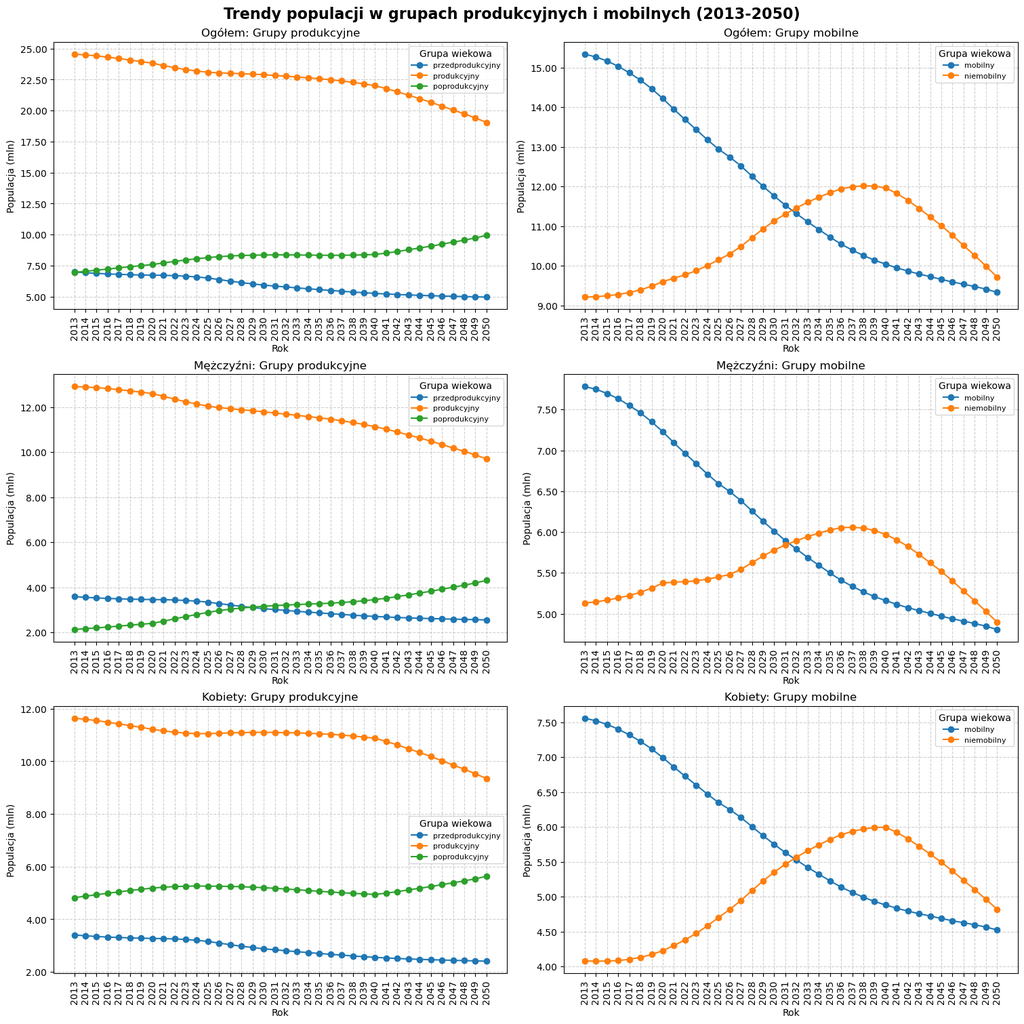

```python
from IPython.display import display, HTML
import matplotlib.pyplot as plt

def plot_population_trends(ax, pivot_table, groups, title):
    for group in groups:
        ax.plot(
            pivot_table.columns,
            pivot_table.loc[group] / 1_000_000,
            marker='o',
            label=group
        )
    ax.set_title(title, fontsize=12)
    ax.set_xlabel('Rok', fontsize=10)
    ax.set_ylabel('Populacja (mln)', fontsize=10)
    ax.legend(title='Grupa wiekowa', fontsize=8)
    ax.grid(True, linestyle='--', alpha=0.6)
    ax.tick_params(axis='x', labelrotation=90)
    ax.yaxis.set_major_formatter(plt.FuncFormatter(lambda x, _: f'{x:.2f}'))


display_table_with_header(pivot_table_func_groups_num_all, "Prognoza ludności w Polsce 2013 - 2050 (liczby bezwzględne): Wartości ogólne")
display_table_with_header(pivot_table_func_groups_num_man, "Prognoza ludności w Polsce 2013 - 2050 (liczby bezwzględne): Mężczyźni")
display_table_with_header(pivot_table_func_groups_num_wom, "Prognoza ludności w Polsce 2013 - 2050 (liczby bezwzględne): Kobiety")

functional_groups = ['przedprodukcyjny', 'produkcyjny', 'poprodukcyjny']
mobility_groups = ['mobilny', 'niemobilny']

fig, axes = plt.subplots(3, 2, figsize=(15, 15), constrained_layout=True)

plot_population_trends(axes[0, 0], pivot_table_func_groups_num_all, functional_groups, 'Ogółem: Grupy produkcyjne')
plot_population_trends(axes[0, 1], pivot_table_func_groups_num_all, mobility_groups, 'Ogółem: Grupy mobilne')

plot_population_trends(axes[1, 0], pivot_table_func_groups_num_man, functional_groups, 'Mężczyźni: Grupy produkcyjne')
plot_population_trends(axes[1, 1], pivot_table_func_groups_num_man, mobility_groups, 'Mężczyźni: Grupy mobilne')

plot_population_trends(axes[2, 0], pivot_table_func_groups_num_wom, functional_groups, 'Kobiety: Grupy produkcyjne')
plot_population_trends(axes[2, 1], pivot_table_func_groups_num_wom, mobility_groups, 'Kobiety: Grupy mobilne')

fig.suptitle('Trendy populacji w grupach produkcyjnych i mobilnych (2013-2050)', fontsize=16, weight='bold')

plt.show()
```

Dane procentowe zostały wygenerowane poprzez zastosowanie metody `pct_change` w bibliotekach Python (**Pandas**). Metoda ta pozwala na obliczenie względnej zmiany wartości w kolejnych latach, co przedstawia tempo wzrostu lub spadku populacji w badanych grupach wiekowych. Zmiany obliczono osobno dla:

- **Ogólnych wartości:** bez podziału na płeć.
- **Mężczyzn:** w każdej z badanych grup wiekowych.
- **Kobiet:** w każdej z badanych grup wiekowych.

Wyniki przedstawiono na mapach cieplnych, które ułatwiają identyfikację najbardziej dynamicznych okresów zmian. Czerwone odcienie wskazują na największe wzrosty procentowe, a niebieskie na największe spadki. Wartości bliskie zeru są oznaczone jako neutralne.

## Opis wykresów

Prezentacja procentowych zmian rok do roku jest szczególnie przydatna w analizach trendów demograficznych, ponieważ pozwala zidentyfikować okresy krytyczne, takie jak nagłe spadki lub wzrosty populacji w określonych grupach wiekowych.

## Wyniki analizy

Poniżej znajdują się tabele przestawne z procentowymi zmianami oraz ich wizualizacja w formie map cieplnych:

Procentowe zmiany w populacji - Ogółem (2013-2050)

| Rok Wiek | 2013 | 2014 | 2015 | 2016 | 2017 | 2018 | 2019 | 2020 | 2021 | 2022 | 2023 | 2024 | 2025 | 2026 | 2027 | 2028 | 2029 | 2030 | 2031 | 2032 | 2033 | 2034 | 2035 | 2036 | 2037 | 2038 | 2039 | 2040 | 2041 | … |
| --- | --- | --- | --- | --- | --- | --- | --- | --- | --- | --- | --- | --- | --- | --- | --- | --- | --- | --- | --- | --- | --- | --- | --- | --- | --- | --- | --- | --- | --- | --- |
| mobilny | 0% | -0.46% | -0.68% | -0.88% | -1.09% | -1.25% | -1.47% | -1.71% | -1.9% | -1.87% | -1.85% | -1.9% | -1.8% | -1.53% | -1.74% | -2.08% | -2.1% | -2.03% | -2.01% | -1.83% | -1.82% | -1.74% | -1.74% | -1.66% | -1.43% | -1.3% | -1.18% | -0.98% | -0.92% | … |
| niemobilny | 0% | 0.12% | 0.26% | 0.34% | 0.53% | 0.73% | 0.97% | 1.22% | 0.9% | 0.88% | 1.06% | 1.31% | 1.46% | 1.43% | 1.85% | 2.15% | 2.04% | 1.86% | 1.56% | 1.35% | 1.25% | 1.08% | 0.99% | 0.81% | 0.44% | 0.21% | -0.06% | -0.39% | -1.16% | … |
| poprodukcyjny | 0% | 1.3% | 1.29% | 1.32% | 1.3% | 1.26% | 1.19% | 1.1% | 1.72% | 1.65% | 1.44% | 1.3% | 1.1% | 0.94% | 0.68% | 0.46% | 0.29% | 0.19% | 0.09% | -0.02% | -0.08% | -0.12% | -0.11% | -0.08% | 0.05% | 0.13% | 0.26% | 0.37% | 1.32% | … |
| produkcyjny | 0% | -0.24% | -0.32% | -0.42% | -0.47% | -0.48% | -0.52% | -0.55% | -0.77% | -0.74% | -0.64% | -0.54% | -0.4% | -0.23% | -0.14% | -0.15% | -0.17% | -0.18% | -0.28% | -0.25% | -0.27% | -0.3% | -0.33% | -0.36% | -0.44% | -0.49% | -0.57% | -0.66% | -1.05% | … |
| przedprodukcyjny | 0% | -0.93% | -0.78% | -0.62% | -0.49% | -0.46% | -0.34% | -0.2% | -0.21% | -0.37% | -0.63% | -0.94% | -1.34% | -1.88% | -2.03% | -1.85% | -1.67% | -1.65% | -1.27% | -1.33% | -1.27% | -1.22% | -1.2% | -1.21% | -1.19% | -1.15% | -1.08% | -0.99% | -0.89% | … |

Procentowe zmiany w populacji - Mężczyźni (2013-2050)

| Rok Wiek | 2013 | 2014 | 2015 | 2016 | 2017 | 2018 | 2019 | 2020 | 2021 | 2022 | 2023 | 2024 | 2025 | 2026 | 2027 | 2028 | 2029 | 2030 | 2031 | 2032 | 2033 | 2034 | 2035 | 2036 | 2037 | 2038 | 2039 | 2040 | 2041 | … |
| --- | --- | --- | --- | --- | --- | --- | --- | --- | --- | --- | --- | --- | --- | --- | --- | --- | --- | --- | --- | --- | --- | --- | --- | --- | --- | --- | --- | --- | --- | --- |
| mobilny | 0% | -0.43% | -0.66% | -0.84% | -1.07% | -1.22% | -1.45% | -1.68% | -1.87% | -1.83% | -1.81% | -1.86% | -1.74% | -1.47% | -1.69% | -2.0% | -2.03% | -1.96% | -1.94% | -1.77% | -1.75% | -1.69% | -1.69% | -1.62% | -1.38% | -1.26% | -1.12% | -0.93% | -0.9% | … |
| niemobilny | 0% | 0.28% | 0.43% | 0.49% | 0.59% | 0.76% | 0.97% | 1.15% | 0.24% | 0.08% | 0.21% | 0.38% | 0.49% | 0.56% | 1.11% | 1.49% | 1.46% | 1.31% | 1.05% | 0.91% | 0.84% | 0.72% | 0.64% | 0.48% | 0.08% | -0.16% | -0.48% | -0.83% | -1.09% | … |
| poprodukcyjny | 0% | 1.65% | 1.65% | 1.7% | 1.88% | 1.82% | 1.75% | 1.67% | 4.03% | 4.15% | 3.78% | 3.6% | 3.25% | 2.79% | 2.13% | 1.64% | 1.31% | 1.15% | 0.98% | 0.79% | 0.67% | 0.6% | 0.62% | 0.68% | 0.9% | 1.04% | 1.29% | 1.51% | 1.77% | … |
| produkcyjny | 0% | -0.15% | -0.23% | -0.31% | -0.4% | -0.41% | -0.45% | -0.49% | -0.97% | -1.01% | -0.93% | -0.87% | -0.74% | -0.55% | -0.41% | -0.38% | -0.38% | -0.38% | -0.48% | -0.44% | -0.44% | -0.46% | -0.49% | -0.52% | -0.61% | -0.67% | -0.78% | -0.88% | -1.0% | … |
| przedprodukcyjny | 0% | -0.91% | -0.76% | -0.61% | -0.47% | -0.44% | -0.32% | -0.18% | -0.19% | -0.37% | -0.61% | -0.92% | -1.32% | -1.84% | -2.0% | -1.84% | -1.67% | -1.64% | -1.25% | -1.33% | -1.27% | -1.22% | -1.2% | -1.21% | -1.19% | -1.15% | -1.08% | -0.99% | -0.89% | … |

Procentowe zmiany w populacji - Kobiety (2013-2050)

| Rok Wiek | 2013 | 2014 | 2015 | 2016 | 2017 | 2018 | 2019 | 2020 | 2021 | 2022 | 2023 | 2024 | 2025 | 2026 | 2027 | 2028 | 2029 | 2030 | 2031 | 2032 | 2033 | 2034 | 2035 | 2036 | 2037 | 2038 | 2039 | 2040 | 2041 | … |
| --- | --- | --- | --- | --- | --- | --- | --- | --- | --- | --- | --- | --- | --- | --- | --- | --- | --- | --- | --- | --- | --- | --- | --- | --- | --- | --- | --- | --- | --- | --- |
| mobilny | 0% | -0.48% | -0.69% | -0.91% | -1.11% | -1.27% | -1.49% | -1.75% | -1.94% | -1.91% | -1.89% | -1.94% | -1.87% | -1.59% | -1.79% | -2.16% | -2.17% | -2.11% | -2.08% | -1.89% | -1.89% | -1.79% | -1.8% | -1.71% | -1.48% | -1.35% | -1.24% | -1.02% | -0.95% | … |
| niemobilny | 0% | -0.09% | 0.05% | 0.15% | 0.46% | 0.69% | 0.98% | 1.32% | 1.74% | 1.89% | 2.11% | 2.43% | 2.6% | 2.43% | 2.68% | 2.9% | 2.68% | 2.46% | 2.1% | 1.83% | 1.68% | 1.46% | 1.35% | 1.16% | 0.81% | 0.58% | 0.37% | 0.06% | -1.24% | … |
| poprodukcyjny | 0% | 1.14% | 1.12% | 1.16% | 1.04% | 1.01% | 0.94% | 0.84% | 0.66% | 0.46% | 0.28% | 0.11% | -0.04% | -0.08% | -0.14% | -0.22% | -0.32% | -0.38% | -0.45% | -0.52% | -0.54% | -0.57% | -0.57% | -0.56% | -0.5% | -0.48% | -0.45% | -0.41% | 1.0% | … |
| produkcyjny | 0% | -0.35% | -0.43% | -0.54% | -0.55% | -0.57% | -0.6% | -0.62% | -0.56% | -0.45% | -0.31% | -0.18% | -0.02% | 0.12% | 0.16% | 0.1% | 0.06% | 0.04% | -0.06% | -0.06% | -0.09% | -0.13% | -0.16% | -0.2% | -0.26% | -0.31% | -0.36% | -0.43% | -1.11% | … |
| przedprodukcyjny | 0% | -0.94% | -0.81% | -0.62% | -0.52% | -0.48% | -0.36% | -0.21% | -0.23% | -0.38% | -0.66% | -0.95% | -1.37% | -1.91% | -2.06% | -1.86% | -1.68% | -1.65% | -1.28% | -1.32% | -1.27% | -1.22% | -1.2% | -1.21% | -1.19% | -1.15% | -1.08% | -0.99% | -0.89% | … |

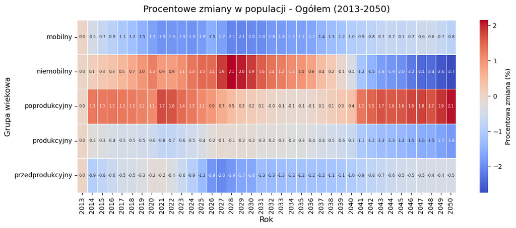

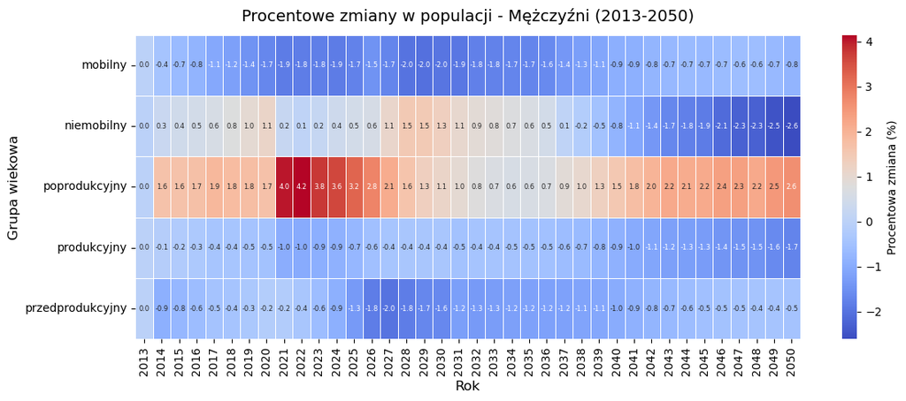

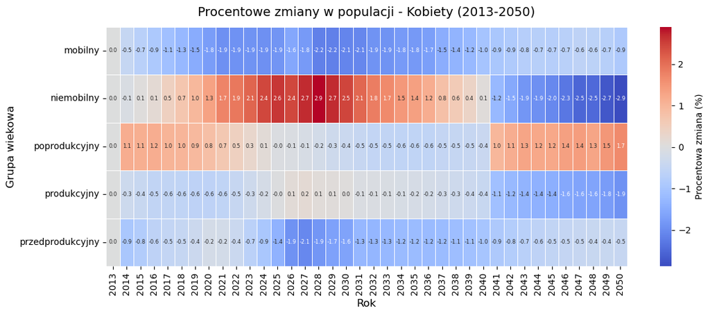

```python
import seaborn as sns
import matplotlib.pyplot as plt

def plot_heatmap(df, title):
    numeric_data = df.apply(lambda x: x.str.replace('%', '').astype(float))
    numeric_data.columns = numeric_data.columns.get_level_values(0)

    plt.figure(figsize=(12, 5))
    sns.heatmap(
        numeric_data,
        annot=True,
        fmt=".1f",
        cmap="coolwarm",
        cbar_kws={'label': 'Procentowa zmiana (%)'},
        annot_kws={'fontsize': 6},
        linewidths=0.5
    )
    plt.title(title, fontsize=14, pad=12)
    plt.xlabel('Rok', fontsize=12)
    plt.ylabel('Grupa wiekowa', fontsize=12)
    plt.xticks(rotation=90)
    plt.tight_layout()
    plt.show()

display_table_with_header(pivot_table_func_groups_pct_all, 'Procentowe zmiany w populacji - Ogółem (2013-2050)')
display_table_with_header(pivot_table_func_groups_pct_man, 'Procentowe zmiany w populacji - Mężczyźni (2013-2050)')
display_table_with_header(pivot_table_func_groups_pct_wom, 'Procentowe zmiany w populacji - Kobiety (2013-2050)')

plot_heatmap(pivot_table_func_groups_pct_all, 'Procentowe zmiany w populacji - Ogółem (2013-2050)')
plot_heatmap(pivot_table_func_groups_pct_man, 'Procentowe zmiany w populacji - Mężczyźni (2013-2050)')
plot_heatmap(pivot_table_func_groups_pct_wom, 'Procentowe zmiany w populacji - Kobiety (2013-2050)')
```

# Analiza #2 - trendy populacji w funkcjonalnych grupach wieku w Polsce (2013-2050) - podział na lokalizacje (miasto i wieś)

W drugiej części analizy dokonano dodatkowego podziału populacji na lokalizacje: **miasto** i **wieś**. Uwzględniono zarówno wartości ogólne, jak i szczegółowy podział według płci (**kobiety** i **mężczyźni**). W wyniku tego podziału powstało łącznie **12 wykresów liniowych**, które ilustrują zmiany populacji w analizowanych grupach wiekowych i mobilnych.

## Opis wykresów

Wykresy przedstawiają trendy demograficzne dla różnych lokalizacji oraz grup wiekowych. Dla każdej lokalizacji (miasto, wieś) stworzono oddzielne wykresy dla:

- **Grup produkcyjnych:**
  - **Wiek przedprodukcyjny** (0-17 lat)
  - **Wiek produkcyjny** (18 lat do wieku emerytalnego)
  - **Wiek poprodukcyjny** (powyżej wieku emerytalnego)
- **Grup mobilnych:**
  - **Wiek mobilny** (18-44 lata)
  - **Wiek niemobilny** (45 lat do wieku emerytalnego)

Dla każdego wykresu wyróżniono podział na płeć, co pozwala na identyfikację różnic w trendach pomiędzy kobietami a mężczyznami w analizowanych grupach wiekowych.

## Obserwacje

- **Miasto:** W miastach zauważalne jest stopniowe zmniejszanie liczby osób w grupach przedprodukcyjnych i produkcyjnych, podczas gdy populacja osób w grupie poprodukcyjnej wykazuje wzrost.
- **Wieś:** Podobne trendy obserwuje się na obszarach wiejskich, jednak tempo zmian w poszczególnych grupach wiekowych różni się od tego w miastach. Spadek populacji w grupach przedprodukcyjnych i mobilnych na wsiach jest wolniejszy, natomiast obserwuje się dla tej grupy większy wzrost liczby osób w grupie poprodukcyjnej.
- **Płeć:** Trendy w podziale na kobiety i mężczyzn są podobne, z pewnymi różnicami w liczebności grup mobilnych i niemobilnych.

Zmniejszanie populacji w grupie produkcyjnej oraz wzrost liczby osób w wieku poprodukcyjnym wskazują na dalsze starzenie się społeczeństwa, co może mieć istotny wpływ na rynek pracy i politykę społeczną w Polsce.

## Tabele przestawne i wykresy

Poniżej zaprezentowano szczegółowe tabele przestawne oraz wykresy liniowe przedstawiające zmiany w populacji w analizowanych grupach wiekowych i mobilnych:

Prognoza ludności w podziale na wieś i miasto - 2013 - 2050 (liczby bezwzględne): Wartości ogólne

| Lokalizacja | Wiek | 2013 | 2014 | 2015 | 2016 | 2017 | 2018 | 2019 | 2020 | 2021 | 2022 | 2023 | 2024 | 2025 | 2026 | 2027 | 2028 | 2029 | 2030 | 2031 | 2032 | 2033 | 2034 | 2035 | 2036 | 2037 | 2038 | 2039 | 2040 | … |
| --- | --- | --- | --- | --- | --- | --- | --- | --- | --- | --- | --- | --- | --- | --- | --- | --- | --- | --- | --- | --- | --- | --- | --- | --- | --- | --- | --- | --- | --- | --- |
| Miasto | mobilny | 9172047 | 9104604 | 9017303 | 8907622 | 8779120 | 8638333 | 8478329 | 8297079 | 8101311 | 7912484 | 7728641 | 7543628 | 7370396 | 7221971 | 7062798 | 6881773 | 6705415 | 6541492 | 6386340 | 6248687 | 6117362 | 5996463 | 5880223 | 5775195 | 5691805 | 5614854 | 5545066 | 5490408 | … |
|  | niemobilny | 5684169 | 5644584 | 5616948 | 5594695 | 5587434 | 5594837 | 5620348 | 5665950 | 5698885 | 5734972 | 5786125 | 5856953 | 5939787 | 6025459 | 6137966 | 6273862 | 6404911 | 6523235 | 6621411 | 6705178 | 6779708 | 6841108 | 6893232 | 6929167 | 6933585 | 6923742 | 6894978 | 6840330 | … |
|  | poprodukcyjny | 4522171 | 4596381 | 4669108 | 4742128 | 4812089 | 4878241 | 4939184 | 4993540 | 5074233 | 5149401 | 5211440 | 5263639 | 5303305 | 5331180 | 5344820 | 5346359 | 5336759 | 5321897 | 5301131 | 5273694 | 5243305 | 5210647 | 5179217 | 5150346 | 5127938 | 5109706 | 5099355 | 5095838 | … |
|  | produkcyjny | 14856216 | 14749188 | 14634251 | 14502317 | 14366554 | 14233170 | 14098677 | 13963029 | 13800196 | 13647456 | 13514766 | 13400581 | 13310183 | 13247430 | 13200764 | 13155635 | 13110326 | 13064727 | 13007751 | 12953865 | 12897070 | 12837571 | 12773455 | 12704362 | 12625390 | 12538596 | 12440044 | 12330738 | … |
|  | przedprodukcyjny | 3893277 | 3856841 | 3826028 | 3807536 | 3793244 | 3778526 | 3767023 | 3759923 | 3749990 | 3731728 | 3702506 | 3660400 | 3602710 | 3525176 | 3442038 | 3365815 | 3297492 | 3231602 | 3179629 | 3128286 | 3080393 | 3035502 | 2992564 | 2950245 | 2909974 | 2872451 | 2838295 | 2807795 | … |
| Wieś | mobilny | 6165805 | 6163292 | 6147509 | 6123909 | 6088922 | 6044569 | 5988717 | 5922126 | 5847259 | 5775054 | 5705995 | 5635873 | 5571310 | 5522130 | 5459573 | 5380624 | 5299918 | 5220073 | 5139070 | 5066058 | 4991676 | 4919410 | 4845249 | 4771855 | 4704347 | 4645903 | 4594944 | 4550697 | … |
|  | niemobilny | 3526044 | 3576231 | 3627941 | 3681726 | 3738185 | 3798758 | 3864591 | 3934890 | 3988325 | 4037803 | 4090158 | 4148347 | 4211156 | 4270424 | 4348054 | 4437997 | 4525195 | 4609939 | 4684950 | 4754363 | 4823075 | 4886960 | 4950524 | 5010986 | 5059413 | 5094067 | 5115542 | 5123812 | … |
|  | poprodukcyjny | 2430061 | 2446076 | 2463882 | 2485371 | 2509480 | 2535608 | 2563106 | 2591333 | 2641433 | 2693958 | 2744814 | 2795836 | 2845044 | 2893395 | 2935806 | 2972575 | 3005931 | 3037025 | 3065429 | 3091321 | 3115169 | 3138085 | 3160377 | 3182993 | 3209657 | 3238516 | 3270179 | 3304993 | … |
|  | produkcyjny | 9691849 | 9739523 | 9775450 | 9805635 | 9827107 | 9843327 | 9853308 | 9857016 | 9835584 | 9812857 | 9796153 | 9784220 | 9782466 | 9792554 | 9807627 | 9818621 | 9825113 | 9830012 | 9824020 | 9820421 | 9814751 | 9806370 | 9795773 | 9782841 | 9763760 | 9739970 | 9710486 | 9674509 | … |
|  | przedprodukcyjny | 3102085 | 3073743 | 3050287 | 3026403 | 3006989 | 2990660 | 2979254 | 2972963 | 2968878 | 2962008 | 2948896 | 2928634 | 2897754 | 2853293 | 2806964 | 2767533 | 2733180 | 2699810 | 2676674 | 2650400 | 2625000 | 2600187 | 2575385 | 2550218 | 2524976 | 2500197 | 2476488 | 2454359 | … |

Prognoza ludności w podziale na wieś i miasto - 2013 - 2050 (liczby bezwzględne): Mężczyźni

| Lokalizacja | Wiek | 2013 | 2014 | 2015 | 2016 | 2017 | 2018 | 2019 | 2020 | 2021 | 2022 | 2023 | 2024 | 2025 | 2026 | 2027 | 2028 | 2029 | 2030 | 2031 | 2032 | 2033 | 2034 | 2035 | 2036 | 2037 | 2038 | 2039 | 2040 | … |
| --- | --- | --- | --- | --- | --- | --- | --- | --- | --- | --- | --- | --- | --- | --- | --- | --- | --- | --- | --- | --- | --- | --- | --- | --- | --- | --- | --- | --- | --- | --- |
| Miasto | mobilny | 4600031 | 4566592 | 4522571 | 4468713 | 4404330 | 4334209 | 4254325 | 4163977 | 4066867 | 3973196 | 3881859 | 3789785 | 3704582 | 3632191 | 3553980 | 3465480 | 3379101 | 3299308 | 3223514 | 3156257 | 3092717 | 3033550 | 2976888 | 2925610 | 2884887 | 2847592 | 2814077 | 2787714 | … |
|  | niemobilny | 3086372 | 3074470 | 3068822 | 3065939 | 3067837 | 3076614 | 3093680 | 3118931 | 3115428 | 3108909 | 3109053 | 3117331 | 3130107 | 3147759 | 3184123 | 3234835 | 3284695 | 3328120 | 3362100 | 3390129 | 3413845 | 3432698 | 3446728 | 3453007 | 3442444 | 3424271 | 3394560 | 3351242 | … |
|  | poprodukcyjny | 1357134 | 1384646 | 1411819 | 1439156 | 1468776 | 1496860 | 1523505 | 1548753 | 1609140 | 1672199 | 1729740 | 1784476 | 1833709 | 1873412 | 1901546 | 1920714 | 1933384 | 1943199 | 1949989 | 1953091 | 1954388 | 1954298 | 1955497 | 1958550 | 1966830 | 1978171 | 1995997 | 2018966 | … |
|  | produkcyjny | 7686403 | 7641062 | 7591393 | 7534652 | 7472167 | 7410823 | 7348005 | 7282908 | 7182295 | 7082105 | 6990912 | 6907116 | 6834689 | 6779950 | 6738103 | 6700315 | 6663796 | 6627428 | 6585614 | 6546386 | 6506562 | 6466248 | 6423616 | 6378617 | 6327331 | 6271863 | 6208637 | 6138956 | … |
|  | przedprodukcyjny | 1995879 | 1978326 | 1963749 | 1954177 | 1946967 | 1939568 | 1933804 | 1930294 | 1925580 | 1916092 | 1901256 | 1879892 | 1850666 | 1811409 | 1769076 | 1730001 | 1694683 | 1660766 | 1634175 | 1607765 | 1583140 | 1560041 | 1537956 | 1516190 | 1495487 | 1476189 | 1458630 | 1442951 | … |
| Wieś | mobilny | 3181244 | 3181238 | 3173992 | 3162863 | 3145729 | 3123949 | 3095910 | 3062980 | 3025243 | 2989066 | 2954618 | 2919726 | 2887980 | 2863471 | 2831793 | 2792735 | 2752179 | 2712018 | 2671143 | 2633975 | 2596042 | 2559264 | 2521271 | 2483502 | 2449588 | 2419870 | 2394464 | 2372317 | … |
|  | niemobilny | 2043706 | 2070083 | 2097706 | 2125960 | 2154492 | 2185348 | 2219326 | 2255024 | 2271538 | 2282454 | 2293376 | 2305594 | 2319475 | 2332342 | 2357006 | 2388921 | 2420899 | 2452062 | 2478689 | 2503858 | 2529667 | 2553312 | 2577371 | 2599945 | 2615613 | 2624129 | 2624663 | 2617778 | … |
|  | poprodukcyjny | 772105 | 779831 | 788426 | 798569 | 811096 | 824419 | 838295 | 852486 | 888866 | 929593 | 970369 | 1012919 | 1054675 | 1095421 | 1130670 | 1161298 | 1189044 | 1215230 | 1239419 | 1261594 | 1281819 | 1301224 | 1320107 | 1339319 | 1360686 | 1383962 | 1409668 | 1438101 | … |
|  | produkcyjny | 5224950 | 5251321 | 5271698 | 5288823 | 5300221 | 5309297 | 5315236 | 5318004 | 5296781 | 5271520 | 5247994 | 5225320 | 5207455 | 5195813 | 5188799 | 5181656 | 5173078 | 5164080 | 5149832 | 5137833 | 5125709 | 5112576 | 5098642 | 5083447 | 5065201 | 5043999 | 5019127 | 4990095 | … |
|  | przedprodukcyjny | 1593064 | 1577915 | 1565506 | 1553596 | 1544241 | 1536328 | 1530965 | 1528092 | 1526291 | 1523140 | 1516982 | 1506842 | 1491237 | 1468848 | 1445663 | 1425540 | 1408107 | 1391012 | 1379404 | 1365856 | 1352769 | 1339987 | 1327206 | 1314240 | 1301227 | 1288467 | 1276248 | 1264847 | … |

Prognoza ludności w podziale na wieś i miasto - 2013 - 2050 (liczby bezwzględne): Kobiety

| Lokalizacja | Wiek | 2013 | 2014 | 2015 | 2016 | 2017 | 2018 | 2019 | 2020 | 2021 | 2022 | 2023 | 2024 | 2025 | 2026 | 2027 | 2028 | 2029 | 2030 | 2031 | 2032 | 2033 | 2034 | 2035 | 2036 | 2037 | 2038 | 2039 | 2040 | … |
| --- | --- | --- | --- | --- | --- | --- | --- | --- | --- | --- | --- | --- | --- | --- | --- | --- | --- | --- | --- | --- | --- | --- | --- | --- | --- | --- | --- | --- | --- | --- |
| Miasto | mobilny | 4572016 | 4538012 | 4494732 | 4438909 | 4374790 | 4304124 | 4224004 | 4133102 | 4034444 | 3939288 | 3846782 | 3753843 | 3665814 | 3589780 | 3508818 | 3416293 | 3326314 | 3242184 | 3162826 | 3092430 | 3024645 | 2962913 | 2903335 | 2849585 | 2806918 | 2767262 | 2730989 | 2702694 | … |
|  | niemobilny | 2597797 | 2570114 | 2548126 | 2528756 | 2519597 | 2518223 | 2526668 | 2547019 | 2583457 | 2626063 | 2677072 | 2739622 | 2809680 | 2877700 | 2953843 | 3039027 | 3120216 | 3195115 | 3259311 | 3315049 | 3365863 | 3408410 | 3446504 | 3476160 | 3491141 | 3499471 | 3500418 | 3489088 | … |
|  | poprodukcyjny | 3165037 | 3211735 | 3257289 | 3302972 | 3343313 | 3381381 | 3415679 | 3444787 | 3465093 | 3477202 | 3481700 | 3479163 | 3469596 | 3457768 | 3443274 | 3425645 | 3403375 | 3378698 | 3351142 | 3320603 | 3288917 | 3256349 | 3223720 | 3191796 | 3161108 | 3131535 | 3103358 | 3076872 | … |
|  | produkcyjny | 7169813 | 7108126 | 7042858 | 6967665 | 6894387 | 6822347 | 6750672 | 6680121 | 6617901 | 6565351 | 6523854 | 6493465 | 6475494 | 6467480 | 6462661 | 6455320 | 6446530 | 6437299 | 6422137 | 6407479 | 6390508 | 6371323 | 6349839 | 6325745 | 6298059 | 6266733 | 6231407 | 6191782 | … |
|  | przedprodukcyjny | 1897398 | 1878515 | 1862279 | 1853359 | 1846277 | 1838958 | 1833219 | 1829629 | 1824410 | 1815636 | 1801250 | 1780508 | 1752044 | 1713767 | 1672962 | 1635814 | 1602809 | 1570836 | 1545454 | 1520521 | 1497253 | 1475461 | 1454608 | 1434055 | 1414487 | 1396262 | 1379665 | 1364844 | … |
| Wieś | mobilny | 2984561 | 2982054 | 2973517 | 2961046 | 2943193 | 2920620 | 2892807 | 2859146 | 2822016 | 2785988 | 2751377 | 2716147 | 2683330 | 2658659 | 2627780 | 2587889 | 2547739 | 2508055 | 2467927 | 2432083 | 2395634 | 2360146 | 2323978 | 2288353 | 2254759 | 2226033 | 2200480 | 2178380 | … |
|  | niemobilny | 1482338 | 1506148 | 1530235 | 1555766 | 1583693 | 1613410 | 1645265 | 1679866 | 1716787 | 1755349 | 1796782 | 1842753 | 1891681 | 1938082 | 1991048 | 2049076 | 2104296 | 2157877 | 2206261 | 2250505 | 2293408 | 2333648 | 2373153 | 2411041 | 2443800 | 2469938 | 2490879 | 2506034 | … |
|  | poprodukcyjny | 1657956 | 1666245 | 1675456 | 1686802 | 1698384 | 1711189 | 1724811 | 1738847 | 1752567 | 1764365 | 1774445 | 1782917 | 1790369 | 1797974 | 1805136 | 1811277 | 1816887 | 1821795 | 1826010 | 1829727 | 1833350 | 1836861 | 1840270 | 1843674 | 1848971 | 1854554 | 1860511 | 1866892 | … |
|  | produkcyjny | 4466899 | 4488202 | 4503752 | 4516812 | 4526886 | 4534030 | 4538072 | 4539012 | 4538803 | 4541337 | 4548159 | 4558900 | 4575011 | 4596741 | 4618828 | 4636965 | 4652035 | 4665932 | 4674188 | 4682588 | 4689042 | 4693794 | 4697131 | 4699394 | 4698559 | 4695971 | 4691359 | 4684414 | … |
|  | przedprodukcyjny | 1509021 | 1495828 | 1484781 | 1472807 | 1462748 | 1454332 | 1448289 | 1444871 | 1442587 | 1438868 | 1431914 | 1421792 | 1406517 | 1384445 | 1361301 | 1341993 | 1325073 | 1308798 | 1297270 | 1284544 | 1272231 | 1260200 | 1248179 | 1235978 | 1223749 | 1211730 | 1200240 | 1189512 | … |

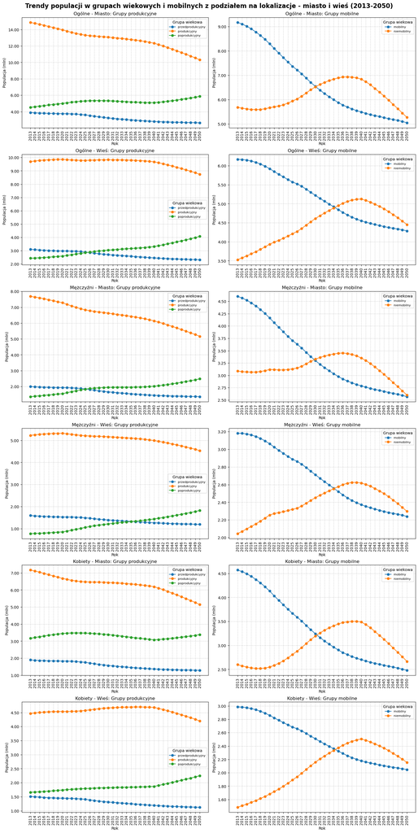

```python
import matplotlib.pyplot as plt
import pandas as pd


def plot_multilevel_population(ax, pivot_table, location, groups, title):
    if isinstance(pivot_table.columns, pd.MultiIndex):
        pivot_table.columns = pivot_table.columns.get_level_values(-1)
    location_data = pivot_table.loc[location]

    years = location_data.columns

    for group in groups:
        ax.plot(
            years,
            location_data.loc[group] / 1_000_000,
            marker='o',
            label=group
        )
    ax.set_title(title, fontsize=12)
    ax.set_xlabel('Rok', fontsize=10)
    ax.set_ylabel('Populacja (mln)', fontsize=10)
    ax.legend(title='Grupa wiekowa', fontsize=8)
    ax.grid(True, linestyle='--', alpha=0.6)
    ax.tick_params(axis='x', labelrotation=90)
    ax.set_xticks(years)
    ax.yaxis.set_major_formatter(plt.FuncFormatter(lambda x, _: f'{x:.2f}'))

functional_groups = ['przedprodukcyjny', 'produkcyjny', 'poprodukcyjny']
mobility_groups = ['mobilny', 'niemobilny']


fig, axes = plt.subplots(6, 2, figsize=(15, 30), constrained_layout=True)

display_table_with_header(pivot_table_location_num_all, "Prognoza ludności w podziale na wieś i miasto - 2013 - 2050 (liczby bezwzględne): Wartości ogólne")
display_table_with_header(pivot_table_location_num_man, "Prognoza ludności w podziale na wieś i miasto - 2013 - 2050 (liczby bezwzględne): Mężczyźni")
display_table_with_header(pivot_table_location_num_wom, "Prognoza ludności w podziale na wieś i miasto - 2013 - 2050 (liczby bezwzględne): Kobiety")

plot_multilevel_population(axes[0, 0], pivot_table_location_num_all, 'Miasto', functional_groups, 'Ogólne - Miasto: Grupy produkcyjne')
plot_multilevel_population(axes[0, 1], pivot_table_location_num_all, 'Miasto', mobility_groups, 'Ogólne - Miasto: Grupy mobilne')
plot_multilevel_population(axes[1, 0], pivot_table_location_num_all, 'Wieś', functional_groups, 'Ogólne - Wieś: Grupy produkcyjne')
plot_multilevel_population(axes[1, 1], pivot_table_location_num_all, 'Wieś', mobility_groups, 'Ogólne - Wieś: Grupy mobilne')


plot_multilevel_population(axes[2, 0], pivot_table_location_num_man, 'Miasto', functional_groups, 'Mężczyźni - Miasto: Grupy produkcyjne')
plot_multilevel_population(axes[2, 1], pivot_table_location_num_man, 'Miasto', mobility_groups, 'Mężczyźni - Miasto: Grupy mobilne')
plot_multilevel_population(axes[3, 0], pivot_table_location_num_man, 'Wieś', functional_groups, 'Mężczyźni - Wieś: Grupy produkcyjne')
plot_multilevel_population(axes[3, 1], pivot_table_location_num_man, 'Wieś', mobility_groups, 'Mężczyźni - Wieś: Grupy mobilne')


plot_multilevel_population(axes[4, 0], pivot_table_location_num_wom, 'Miasto', functional_groups, 'Kobiety - Miasto: Grupy produkcyjne')
plot_multilevel_population(axes[4, 1], pivot_table_location_num_wom, 'Miasto', mobility_groups, 'Kobiety - Miasto: Grupy mobilne')
plot_multilevel_population(axes[5, 0], pivot_table_location_num_wom, 'Wieś', functional_groups, 'Kobiety - Wieś: Grupy produkcyjne')
plot_multilevel_population(axes[5, 1], pivot_table_location_num_wom, 'Wieś', mobility_groups, 'Kobiety - Wieś: Grupy mobilne')


fig.suptitle('Trendy populacji w grupach wiekowych i mobilnych z podziałem na lokalizacje - miasto i wieś (2013-2050)', fontsize=16, weight='bold')
plt.show()
```

Wartości procentowe obliczono na podstawie zmian rok do roku, co pozwala łatwo uchwycić kluczowe trendy. Wykorzystanie map cieplnych umożliwia szybkie zauważenie obszarów o największych zmianach, zarówno wzrostowych, jak i spadkowych.

## Obserwacje

Zmiany procentowe w populacji wskazują na postępujące starzenie się społeczeństwa w Polsce. Na terenach miejskich obserwuje się szybsze tempo spadków w młodszych grupach wiekowych, co może wynikać z niższej liczby urodzeń oraz migracji młodych rodzin na tereny podmiejskie. Natomiast na wsiach wzrost liczby osób w grupach poprodukcyjnych jest bardziej wyraźny, co odzwierciedla migracje młodych do miast oraz starzenie się ludności wiejskiej.

Porównanie płci pokazuje, że kobiety dominują liczebnie w grupach poprodukcyjnych, co wynika z ich dłuższej średniej długości życia, podczas gdy w grupach produkcyjnych i mobilnych różnice są mniej zauważalne.

Wyniki analizy przedstawiono poniżej:

Procentowe zmiany w populacji - wartości ogólne (2013-2050) - Miasta i Wsie

| Lokalizacja | Wiek | 2013 | 2014 | 2015 | 2016 | 2017 | 2018 | 2019 | 2020 | 2021 | 2022 | 2023 | 2024 | 2025 | 2026 | 2027 | 2028 | 2029 | 2030 | 2031 | 2032 | 2033 | 2034 | 2035 | 2036 | 2037 | 2038 | 2039 | 2040 | … |
| --- | --- | --- | --- | --- | --- | --- | --- | --- | --- | --- | --- | --- | --- | --- | --- | --- | --- | --- | --- | --- | --- | --- | --- | --- | --- | --- | --- | --- | --- | --- |
| Miasto | mobilny | 0% | -0.74% | -0.96% | -1.22% | -1.44% | -1.6% | -1.85% | -2.14% | -2.36% | -2.33% | -2.32% | -2.39% | -2.3% | -2.01% | -2.2% | -2.56% | -2.56% | -2.44% | -2.37% | -2.16% | -2.1% | -1.98% | -1.94% | -1.79% | -1.44% | -1.35% | -1.24% | -0.99% | … |
|  | niemobilny | 0% | -0.7% | -0.49% | -0.4% | -0.13% | 0.13% | 0.46% | 0.81% | 0.58% | 0.63% | 0.89% | 1.22% | 1.41% | 1.44% | 1.87% | 2.21% | 2.09% | 1.85% | 1.51% | 1.27% | 1.11% | 0.91% | 0.76% | 0.52% | 0.06% | -0.14% | -0.42% | -0.79% | … |
|  | poprodukcyjny | 0% | 1.64% | 1.58% | 1.56% | 1.48% | 1.37% | 1.25% | 1.1% | 1.62% | 1.48% | 1.2% | 1.0% | 0.75% | 0.53% | 0.26% | 0.03% | -0.18% | -0.28% | -0.39% | -0.52% | -0.58% | -0.62% | -0.6% | -0.56% | -0.44% | -0.36% | -0.2% | -0.07% | … |
|  | produkcyjny | 0% | -0.72% | -0.78% | -0.9% | -0.94% | -0.93% | -0.94% | -0.96% | -1.17% | -1.11% | -0.97% | -0.84% | -0.67% | -0.47% | -0.35% | -0.34% | -0.34% | -0.35% | -0.44% | -0.41% | -0.44% | -0.46% | -0.5% | -0.54% | -0.62% | -0.69% | -0.79% | -0.88% | … |
|  | przedprodukcyjny | 0% | -0.94% | -0.8% | -0.48% | -0.38% | -0.39% | -0.3% | -0.19% | -0.26% | -0.49% | -0.78% | -1.14% | -1.58% | -2.15% | -2.36% | -2.21% | -2.03% | -2.0% | -1.61% | -1.61% | -1.53% | -1.46% | -1.41% | -1.41% | -1.37% | -1.29% | -1.19% | -1.07% | … |
| Wieś | mobilny | 0% | -0.04% | -0.26% | -0.38% | -0.57% | -0.73% | -0.92% | -1.11% | -1.26% | -1.23% | -1.2% | -1.23% | -1.15% | -0.88% | -1.13% | -1.45% | -1.5% | -1.51% | -1.55% | -1.42% | -1.47% | -1.45% | -1.51% | -1.51% | -1.41% | -1.24% | -1.1% | -0.96% | … |
|  | niemobilny | 0% | 1.42% | 1.45% | 1.48% | 1.53% | 1.62% | 1.73% | 1.82% | 1.36% | 1.24% | 1.3% | 1.42% | 1.51% | 1.41% | 1.82% | 2.07% | 1.96% | 1.87% | 1.63% | 1.48% | 1.45% | 1.32% | 1.3% | 1.22% | 0.97% | 0.68% | 0.42% | 0.16% | … |
|  | poprodukcyjny | 0% | 0.66% | 0.73% | 0.87% | 0.97% | 1.04% | 1.08% | 1.1% | 1.93% | 1.99% | 1.89% | 1.86% | 1.76% | 1.7% | 1.47% | 1.25% | 1.12% | 1.03% | 0.94% | 0.84% | 0.77% | 0.74% | 0.71% | 0.72% | 0.84% | 0.9% | 0.98% | 1.06% | … |
|  | produkcyjny | 0% | 0.49% | 0.37% | 0.31% | 0.22% | 0.17% | 0.1% | 0.04% | -0.22% | -0.23% | -0.17% | -0.12% | -0.02% | 0.1% | 0.15% | 0.11% | 0.07% | 0.05% | -0.06% | -0.04% | -0.06% | -0.09% | -0.11% | -0.13% | -0.2% | -0.24% | -0.3% | -0.37% | … |
|  | przedprodukcyjny | 0% | -0.91% | -0.76% | -0.78% | -0.64% | -0.54% | -0.38% | -0.21% | -0.14% | -0.23% | -0.44% | -0.69% | -1.05% | -1.53% | -1.62% | -1.4% | -1.24% | -1.22% | -0.86% | -0.98% | -0.96% | -0.95% | -0.95% | -0.98% | -0.99% | -0.98% | -0.95% | -0.89% | … |

Procentowe zmiany w populacji - Kobiety (2013-2050) - Miasta i Wsie

| Lokalizacja | Wiek | 2013 | 2014 | 2015 | 2016 | 2017 | 2018 | 2019 | 2020 | 2021 | 2022 | 2023 | 2024 | 2025 | 2026 | 2027 | 2028 | 2029 | 2030 | 2031 | 2032 | 2033 | 2034 | 2035 | 2036 | 2037 | 2038 | 2039 | 2040 | … |
| --- | --- | --- | --- | --- | --- | --- | --- | --- | --- | --- | --- | --- | --- | --- | --- | --- | --- | --- | --- | --- | --- | --- | --- | --- | --- | --- | --- | --- | --- | --- |
| Miasto | mobilny | 0% | -0.74% | -0.95% | -1.24% | -1.44% | -1.62% | -1.86% | -2.15% | -2.39% | -2.36% | -2.35% | -2.42% | -2.35% | -2.07% | -2.26% | -2.64% | -2.63% | -2.53% | -2.45% | -2.23% | -2.19% | -2.04% | -2.01% | -1.85% | -1.5% | -1.41% | -1.31% | -1.04% | … |
|  | niemobilny | 0% | -1.07% | -0.86% | -0.76% | -0.36% | -0.05% | 0.34% | 0.81% | 1.43% | 1.65% | 1.94% | 2.34% | 2.56% | 2.42% | 2.65% | 2.88% | 2.67% | 2.4% | 2.01% | 1.71% | 1.53% | 1.26% | 1.12% | 0.86% | 0.43% | 0.24% | 0.03% | -0.32% | … |
|  | poprodukcyjny | 0% | 1.48% | 1.42% | 1.4% | 1.22% | 1.14% | 1.01% | 0.85% | 0.59% | 0.35% | 0.13% | -0.07% | -0.27% | -0.34% | -0.42% | -0.51% | -0.65% | -0.73% | -0.82% | -0.91% | -0.95% | -0.99% | -1.0% | -0.99% | -0.96% | -0.94% | -0.9% | -0.85% | … |
|  | produkcyjny | 0% | -0.86% | -0.92% | -1.07% | -1.05% | -1.04% | -1.05% | -1.05% | -0.93% | -0.79% | -0.63% | -0.47% | -0.28% | -0.12% | -0.07% | -0.11% | -0.14% | -0.14% | -0.24% | -0.23% | -0.26% | -0.3% | -0.34% | -0.38% | -0.44% | -0.5% | -0.56% | -0.64% | … |
|  | przedprodukcyjny | 0% | -1.0% | -0.86% | -0.48% | -0.38% | -0.4% | -0.31% | -0.2% | -0.29% | -0.48% | -0.79% | -1.15% | -1.6% | -2.18% | -2.38% | -2.22% | -2.02% | -1.99% | -1.62% | -1.61% | -1.53% | -1.46% | -1.41% | -1.41% | -1.36% | -1.29% | -1.19% | -1.07% | … |
| Wieś | mobilny | 0% | -0.08% | -0.29% | -0.42% | -0.6% | -0.77% | -0.95% | -1.16% | -1.3% | -1.28% | -1.24% | -1.28% | -1.21% | -0.92% | -1.16% | -1.52% | -1.55% | -1.56% | -1.6% | -1.45% | -1.5% | -1.48% | -1.53% | -1.53% | -1.47% | -1.27% | -1.15% | -1.0% | … |
|  | niemobilny | 0% | 1.61% | 1.6% | 1.67% | 1.8% | 1.88% | 1.97% | 2.1% | 2.2% | 2.25% | 2.36% | 2.56% | 2.66% | 2.45% | 2.73% | 2.91% | 2.69% | 2.55% | 2.24% | 2.01% | 1.91% | 1.75% | 1.69% | 1.6% | 1.36% | 1.07% | 0.85% | 0.61% | … |
|  | poprodukcyjny | 0% | 0.5% | 0.55% | 0.68% | 0.69% | 0.75% | 0.8% | 0.81% | 0.79% | 0.67% | 0.57% | 0.48% | 0.42% | 0.42% | 0.4% | 0.34% | 0.31% | 0.27% | 0.23% | 0.2% | 0.2% | 0.19% | 0.19% | 0.18% | 0.29% | 0.3% | 0.32% | 0.34% | … |
|  | produkcyjny | 0% | 0.48% | 0.35% | 0.29% | 0.22% | 0.16% | 0.09% | 0.02% | 0% | 0.06% | 0.15% | 0.24% | 0.35% | 0.47% | 0.48% | 0.39% | 0.32% | 0.3% | 0.18% | 0.18% | 0.14% | 0.1% | 0.07% | 0.05% | -0.02% | -0.06% | -0.1% | -0.15% | … |
|  | przedprodukcyjny | 0% | -0.87% | -0.74% | -0.81% | -0.68% | -0.58% | -0.42% | -0.24% | -0.16% | -0.26% | -0.48% | -0.71% | -1.07% | -1.57% | -1.67% | -1.42% | -1.26% | -1.23% | -0.88% | -0.98% | -0.96% | -0.95% | -0.95% | -0.98% | -0.99% | -0.98% | -0.95% | -0.89% | … |

Procentowe zmiany w populacji - Mężczyźni (2013-2050) - Miasta i wsie

| Lokalizacja | Wiek | 2013 | 2014 | 2015 | 2016 | 2017 | 2018 | 2019 | 2020 | 2021 | 2022 | 2023 | 2024 | 2025 | 2026 | 2027 | 2028 | 2029 | 2030 | 2031 | 2032 | 2033 | 2034 | 2035 | 2036 | 2037 | 2038 | 2039 | 2040 | … |
| --- | --- | --- | --- | --- | --- | --- | --- | --- | --- | --- | --- | --- | --- | --- | --- | --- | --- | --- | --- | --- | --- | --- | --- | --- | --- | --- | --- | --- | --- | --- |
| Miasto | mobilny | 0% | -0.73% | -0.96% | -1.19% | -1.44% | -1.59% | -1.84% | -2.12% | -2.33% | -2.3% | -2.3% | -2.37% | -2.25% | -1.95% | -2.15% | -2.49% | -2.49% | -2.36% | -2.3% | -2.09% | -2.01% | -1.91% | -1.87% | -1.72% | -1.39% | -1.29% | -1.18% | -0.94% | … |
|  | niemobilny | 0% | -0.39% | -0.18% | -0.09% | 0.06% | 0.29% | 0.55% | 0.82% | -0.11% | -0.21% | 0% | 0.27% | 0.41% | 0.56% | 1.16% | 1.59% | 1.54% | 1.32% | 1.02% | 0.83% | 0.7% | 0.55% | 0.41% | 0.18% | -0.31% | -0.53% | -0.87% | -1.28% | … |
|  | poprodukcyjny | 0% | 2.03% | 1.96% | 1.94% | 2.06% | 1.91% | 1.78% | 1.66% | 3.9% | 3.92% | 3.44% | 3.16% | 2.76% | 2.17% | 1.5% | 1.01% | 0.66% | 0.51% | 0.35% | 0.16% | 0.07% | 0% | 0.06% | 0.16% | 0.42% | 0.58% | 0.9% | 1.15% | … |
|  | produkcyjny | 0% | -0.59% | -0.65% | -0.75% | -0.83% | -0.82% | -0.85% | -0.89% | -1.38% | -1.39% | -1.29% | -1.2% | -1.05% | -0.8% | -0.62% | -0.56% | -0.55% | -0.55% | -0.63% | -0.6% | -0.61% | -0.62% | -0.66% | -0.7% | -0.8% | -0.88% | -1.01% | -1.12% | … |
|  | przedprodukcyjny | 0% | -0.88% | -0.74% | -0.49% | -0.37% | -0.38% | -0.3% | -0.18% | -0.24% | -0.49% | -0.77% | -1.12% | -1.55% | -2.12% | -2.34% | -2.21% | -2.04% | -2.0% | -1.6% | -1.62% | -1.53% | -1.46% | -1.42% | -1.42% | -1.37% | -1.29% | -1.19% | -1.07% | … |
| Wieś | mobilny | 0% | 0% | -0.23% | -0.35% | -0.54% | -0.69% | -0.9% | -1.06% | -1.23% | -1.2% | -1.15% | -1.18% | -1.09% | -0.85% | -1.11% | -1.38% | -1.45% | -1.46% | -1.51% | -1.39% | -1.44% | -1.42% | -1.48% | -1.5% | -1.37% | -1.21% | -1.05% | -0.92% | … |
|  | niemobilny | 0% | 1.29% | 1.33% | 1.35% | 1.34% | 1.43% | 1.55% | 1.61% | 0.73% | 0.48% | 0.48% | 0.53% | 0.6% | 0.55% | 1.06% | 1.35% | 1.34% | 1.29% | 1.09% | 1.02% | 1.03% | 0.93% | 0.94% | 0.88% | 0.6% | 0.33% | 0.02% | -0.26% | … |
|  | poprodukcyjny | 0% | 1.0% | 1.1% | 1.29% | 1.57% | 1.64% | 1.68% | 1.69% | 4.27% | 4.58% | 4.39% | 4.38% | 4.12% | 3.86% | 3.22% | 2.71% | 2.39% | 2.2% | 1.99% | 1.79% | 1.6% | 1.51% | 1.45% | 1.46% | 1.6% | 1.71% | 1.86% | 2.02% | … |
|  | produkcyjny | 0% | 0.5% | 0.39% | 0.32% | 0.22% | 0.17% | 0.11% | 0.05% | -0.4% | -0.48% | -0.45% | -0.43% | -0.34% | -0.22% | -0.13% | -0.14% | -0.17% | -0.17% | -0.28% | -0.23% | -0.24% | -0.26% | -0.27% | -0.3% | -0.36% | -0.42% | -0.49% | -0.58% | … |
|  | przedprodukcyjny | 0% | -0.95% | -0.79% | -0.76% | -0.6% | -0.51% | -0.35% | -0.19% | -0.12% | -0.21% | -0.4% | -0.67% | -1.04% | -1.5% | -1.58% | -1.39% | -1.22% | -1.21% | -0.83% | -0.98% | -0.96% | -0.94% | -0.95% | -0.98% | -0.99% | -0.98% | -0.95% | -0.89% | … |

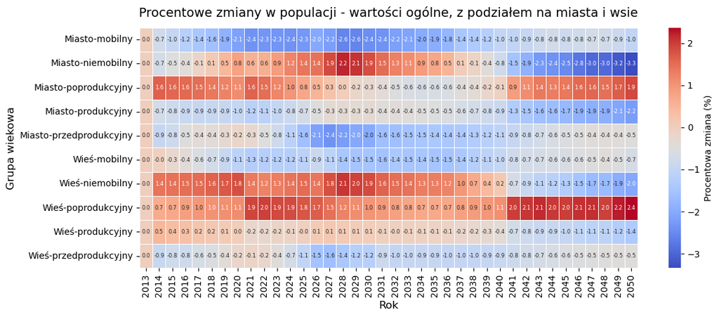

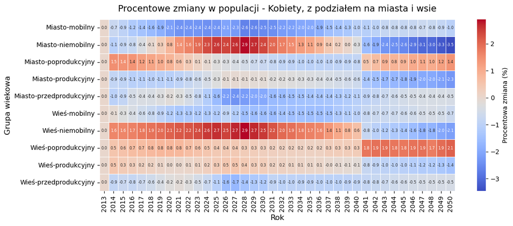

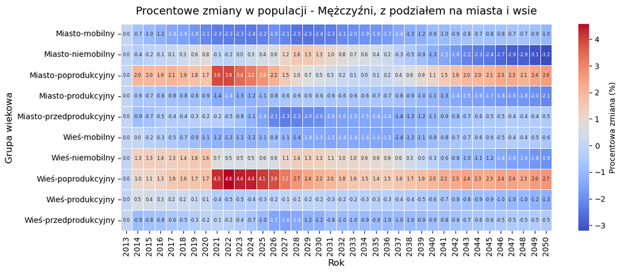

```python
display_table_with_header(pivot_table_location_pct_all, 'Procentowe zmiany w populacji - wartości ogólne (2013-2050) - Miasta i Wsie')
display_table_with_header(pivot_table_location_pct_wom, 'Procentowe zmiany w populacji - Kobiety (2013-2050) - Miasta i Wsie')
display_table_with_header(pivot_table_location_pct_man, 'Procentowe zmiany w populacji - Mężczyźni (2013-2050) - Miasta i wsie')

plot_heatmap(pivot_table_location_pct_all, 'Procentowe zmiany w populacji - wartości ogólne, z podziałem na miasta i wsie')
plot_heatmap(pivot_table_location_pct_wom, 'Procentowe zmiany w populacji - Kobiety, z podziałem na miasta i wsie')
plot_heatmap(pivot_table_location_pct_man, 'Procentowe zmiany w populacji - Mężczyźni, z podziałem na miasta i wsie')
```